# Assignment: GreatLearning

## Submitted by: Anurima Dey

### Dated: 23 Oct 2020

```python
%matplotlib inline

import pandas as pd
import matplotlib.pyplot as plt
import numpy as np
import seaborn as sns
```

```python
# To make prettier and bigger graphs
plt.style.use('ggplot')
plt.rcParams['figure.figsize'] = (15, 5)
plt.rcParams['font.family'] = 'sans-serif'
```

```python
latest = pd.read_excel('../data/latest - orig.xlsx')
latest.head()
```

|  | ProspectID | CreatedOn | mx_Country | mx_Preferred_Campus | mx_Exp_In_Years | DoNotCall | DoNotEmail | mx_Mode_of_Instruction | Source | SourceMedium | ... | mx_Current_Interested_Program | mx_Application_Date | mx_Industry | mx_UG_Degree | mx_UG_Passing_Year | mx_PG_Degree | mx_PG_Passing_Year | mx_Batch_Code | mx_City | mx_Device_details |
| --- | --- | --- | --- | --- | --- | --- | --- | --- | --- | --- | --- | --- | --- | --- | --- | --- | --- | --- | --- | --- | --- |
| 0 | 65e26baf-5ed5-4c08-92a6-426c0f4052b5 | 2019-02-16 20:51:09 | NaN | Mumbai | 2-3 Years | 0 | 0 | Classroom | google | Display | ... | PGPML-Online | NaT | NaN | NaN | NaN | NaN | NaN | NaN | NaN | smartphone \| Xiaomi Redmi 6A \| Android 8.1.0 \|... |
| 1 | a6998bac-67e9-479e-aca9-d2808b4522f1 | 2019-02-07 15:39:26 | NaN | Mumbai | 1-2 Years | 0 | 0 | NaN | facebook | Mumbai - DSEFT - LAE (1%) | ... | DSEFT | NaT | NaN | NaN | NaN | NaN | NaN | NaN | NaN | smartphone \| Xiaomi Redmi 4A \| Android 6.0.1 \|... |
| 2 | c26dbf1b-6e27-44ce-b33f-a090f7acc040 | 2018-12-30 15:19:59 | NaN | Delhi | 2-5 Years | 0 | 0 | NaN | Facebook | LAE-LTV-1% | ... | PGPBA | NaT | Others | NaN | NaN | NaN | NaN | NaN | NaN | smartphone \| Lenovo A7020a48 \| Android 6.0 \| C... |
| 3 | 1ebf4111-94da-4c73-96b7-55dcb74a4336 | 2019-05-31 08:19:16 | Singapore | Online | >15 Years | 0 | 0 | NaN | facebook | LAE1–32to45 | ... | PGPBABI-Online-International | NaT | NaN | NaN | NaN | NaN | NaN | NaN | Singapore | smartphone \| Apple iPhone \| iOS 12.3 \| Mobile ... |
| 4 | aa5b2c0e-bf49-4702-9235-05c7d7b62776 | 2016-12-14 04:59:18 | NaN | Gurgaon | 2-5 Years | 0 | 1 | NaN | Zopim Chat | olp | ... | PGPBA | NaT | IT & Technology | NaN | NaN | NaN | NaN | NaN | Gurgaon | NaN |

5 rows × 24 columns

```python
trails = pd.read_excel('../data/trails - orig.xlsx')
trails.head()
```

|  | RelatedProspectId | ActivityName | Status | mx_Custom_1 | mx_Custom_2 | mx_Custom_3 | mx_Custom_4 | mx_Custom_5 | mx_Custom_6 | mx_Custom_7 | mx_Custom_8 | mx_Custom_9 | mx_Custom_10 | CreatedOn | mx_Country_Post | mx_Preferred_Campus_Post | ProspectStage_Pre | ProspectStage_Post | mx_Current_Interested_Program_Pre | mx_Current_Interested_Program_Post |
| --- | --- | --- | --- | --- | --- | --- | --- | --- | --- | --- | --- | --- | --- | --- | --- | --- | --- | --- | --- | --- |
| 0 | 001eaa91-4d10-4398-b054-10833ce9744a | 91. Change Owner | Active | b8166dce-7f89-11e8-8aa7-020e1b1539ba | NaN | NaN | NaN | NaN | NaN | NaN | NaN | NaN | NaN | 2019-05-11 17:24:42.000 | NaN | Bangalore | Lead Called | Lead Called | PGPBA | PGPBA |
| 1 | 004d4ad9-c722-4fe4-906d-4db4362300d7 | lead_capture | existing_lead | Facebook | BABI - Bangalore | Remarketing | website_landing_page | NaN | NaN | NaN | NaN | NaN | NaN | 2019-02-13 02:46:50.088 | NaN | Bangalore | Lead | Lead | PGPBABI-Online | PGPBABI-Online |
| 2 | 004d4ad9-c722-4fe4-906d-4db4362300d7 | lead_capture | new_lead | google | PGP_BABI_PPC_BMM_Search_Data_Science_Bangalore | search | website_landing_page | NaN | NaN | NaN | NaN | NaN | NaN | 2019-01-04 13:55:13.832 | NaN | Bangalore | NaN | Lead | NaN | PGPBA |
| 3 | 004d4ad9-c722-4fe4-906d-4db4362300d7 | 0.Called at Lead Stage | Call back later | NaN | NaN | NaN | NaN | NaN | NaN | NaN | NaN | NaN | NaN | 2019-01-04 15:09:00.000 | NaN | Bangalore | Lead | Lead Called | PGPBA | PGPBA |
| 4 | 004d4ad9-c722-4fe4-906d-4db4362300d7 | Outbound Phone Call Activity | Answered | Anita - 918049652364 | 2019-01-04 15:08:37 | 37 | http://recordings.kookoo.in/great_learning/gre... | Web | OzonetelV2 | Answered | NaN | answered | NaN | 2019-01-04 15:08:37.000 | NaN | Bangalore | Lead Called | Lead Called | PGPBA | PGPBA |

# Descriptive Analysis

The descriptive analysis will be performed stepwise after doing certain manipulations with the data

**Manipulations**

- Discaring the columns with high missing values
- After discarding, we shall create the two seperate tables.
  1. Quantitative variables table 1 as in question
  2. Qualitative variables table 2 as in question for both DataFrames: latest, trail
- Clean certain columns for univariate analysis.
- Merge the data for bivariate analysis.

## Discarding the columns with high missing values

**Idea:** From both the dataframes 'latest' and 'trials', the columns with more than 30% null values are dropped

```python
# remove columns with missing values


def remove_missing_cols(df, thresh = 30):
    '''
    remove columns with missing values > thresh percentage

    parameters:
    ----------
    df: pd.DataFrame
    thresh: how much percentage of missing values are okay to keep

    '''
    na_perct = df.isna().mean()*100
    valid_cols = na_perct[na_perct <= thresh].index
    return df[valid_cols]
```

```python
latest_use = remove_missing_cols(latest, 30)
```

```python
trail_use = remove_missing_cols(trails, 30)
```

## 1. Creating the first table for quantitative variables

```python
def continuous_var_summary(var):
    '''
    Returns the summary of the data, namely : 'Min', 'Max', 'Avg','% null'

    Parameters:
    ----------------
    var: pd.Series, any pd.DataFrame column

    Return:
    ---------------
    quantity: a DataFrame
    '''
    quantity = {}
    percent = np.arange(0.05, 1, 0.05)
    quantity['Min'] = var.dropna().min()
    quantity['Max'] = var.dropna().max()
    quantity['Avg'] = var.dropna().mean()
    quantity['% null'] = var.isna().mean()*100
    quantity = pd.DataFrame([quantity])
    return quantity
```

```python
score = continuous_var_summary(latest['Score'])
```

```python
#
percentiles = np.arange(0.05, 1, 0.05)
quantile = pd.DataFrame(latest['Score'].quantile(percentiles))
quantile = quantile.T
quantile = quantile.reset_index(drop = True)
quantile.columns = np.round(quantile.columns, 2)
```

```python
result1 = pd.concat([score, quantile], axis = 1)
```

```python
def convert_cols_to_string(cols, n):
    '''
    convert name of the columns to strings

    parameters:
    --------------
    cols: the column name that is to be changed
    n: string conversion to how many digits

    returns:
    --------------
    new_col: returns the converted column
    '''
    new_cols = []
    for col in cols:
        try:
            new_col = str(np.round(col, n))
        except Exception:
            new_col = col

        new_cols.append(new_col)


    return new_cols
```

```python
result1.columns = convert_cols_to_string(result1.columns, 2)
```

```python
result1
```

|  | Min | Max | Avg | % null | 0.05 | 0.1 | 0.15 | 0.2 | 0.25 | 0.3 | ... | 0.5 | 0.55 | 0.6 | 0.65 | 0.7 | 0.75 | 0.8 | 0.85 | 0.9 | 0.95 |
| --- | --- | --- | --- | --- | --- | --- | --- | --- | --- | --- | --- | --- | --- | --- | --- | --- | --- | --- | --- | --- | --- |
| 0 | -48.0 | 1142.0 | 21.165496 | 0.3 | -10.0 | 0.0 | 0.0 | 2.0 | 2.0 | 4.0 | ... | 10.0 | 11.0 | 12.0 | 16.0 | 20.0 | 24.0 | 33.0 | 40.6 | 56.0 | 85.0 |

1 rows × 23 columns

```python
EngagementScore = continuous_var_summary(latest['EngagementScore'])
```

```python
quantile2 = pd.DataFrame(latest['EngagementScore'].quantile(percentiles))
quantile2 = quantile.T
quantile2 = quantile.reset_index(drop = True)
quantile2.columns = np.round(quantile.columns, 2)
```

```python
result2 = pd.concat([EngagementScore, quantile2], axis = 1)
result2.columns = convert_cols_to_string(result2.columns, 2)
```

```python
result2
```

[output not shown]

1 rows × 23 columns

```python
result = pd.concat([result1, result2], axis = 0)
```

```python
result.index = ['Score', 'EngagementScore']
```

### Required table 1: from DataFrame: latest

There is no quantitative variables in the table trails

```python
result
```

[output not shown]

2 rows × 23 columns

## 2. Creating table two for Qualitative variables

```python
def categorical_frequency(ser):
    counts = ser.value_counts()
    counts.name = 'Freq'
    d = pd.DataFrame(counts)
    na_counts = ser.isna().sum()
    valid_counts = ser.shape[0] - na_counts
    d['Freq_percentage'] = d['Freq']/(valid_counts)
    return d
```

```python
def make_categorical_freq_table(cols, df):
    '''Make categorical frequency tables for selected columns <cols>

    Parameters:
    -----------

    cols: list
        The column names of categorical variables

    df: pd.Dataframe

    '''
    frames = []
    for col in cols:
        table = categorical_frequency(df[col])
        frames.append(table)


    return pd.concat(frames, keys=cols)
```

### Table two: DataFrame: latest

```python
# Use this to display all rows
pd.set_option('display.max_rows', 500)

# Use this to reset back
pd.set_option('display.max_rows', 10)
```

```python
cat_cols_latest = ['ProspectStage', 'DoNotCall', 'DoNotEmail', 'mx_Preferred_Campus', 'mx_Exp_In_Years',
            'mx_Current_Interested_Program', 'SourceCampaign']

make_categorical_freq_table(cat_cols_latest, latest_use)
```

|  |  | Freq | Freq_percentage |
| --- | --- | --- | --- |
| ProspectStage | Lead Called | 454 | 0.454000 |
|  | Rejected | 353 | 0.353000 |
|  | Lead | 121 | 0.121000 |
|  | Pending Applicant | 36 | 0.036000 |
|  | Enrolled | 15 | 0.015000 |
| ... | ... | ... | ... |
| SourceCampaign | aiml-unified-Bangalore | 1 | 0.001248 |
|  | Intent Topic_Targeting_Display_PGP_BABI_Bangalore_Performance | 1 | 0.001248 |
|  | 816817389 | 1 | 0.001248 |
|  | PGP-EX_PPC-BMM_Search_Executive_MBA_Gurgaon | 1 | 0.001248 |
|  | dse_Chennai | 1 | 0.001248 |

358 rows × 2 columns

### Table two: DataFrame: trails

```python
cat_cols_trail = ['ActivityName', 'mx_Preferred_Campus_Post', 'ProspectStage_Pre', 'ProspectStage_Post',
                   'mx_Current_Interested_Program_Pre', 'mx_Current_Interested_Program_Post']

make_categorical_freq_table(cat_cols_trail, trail_use)
```

|  |  | Freq | Freq_percentage |
| --- | --- | --- | --- |
| ActivityName | Unique Page Visit | 2211 | 0.322491 |
|  | 0.Called at Lead Stage | 1184 | 0.172695 |
|  | Outbound Phone Call Activity | 1000 | 0.145858 |
|  | lead_capture | 935 | 0.136377 |
|  | 91. Change Owner | 733 | 0.106914 |
| ... | ... | ... | ... |
| mx_Current_Interested_Program_Post | ACSP | 23 | 0.003369 |
|  | ACSP-International | 10 | 0.001465 |
|  | PGPM-Ex | 9 | 0.001318 |
|  | PGPSDM | 6 | 0.000879 |
|  | MLCP | 2 | 0.000293 |

99 rows × 2 columns

## Cleaning Data for Univariate analysis:

We shall here clean the 'max experience in years' column and convert it into float, so that they can be interpreted.

```python
def na_patch(func):
    '''
    Patch function to handle NaN exception

    parameters:
    -----------
    func : any function on which exception is to be handled
    '''
    def modfunc(x, *args, **kwargs):
        try:
            return func(x, *args, **kwargs)
        except Exception:
            return x

    return modfunc
```

```python
@na_patch
def get_numerical_exp(exp_str):
    '''
    Operations:
    1. '<1': returns the lower value experience
    2. '> 15': returns the lower value
    3. value bins: returns the average of the two numbers
    4. single digit strings: returns numerical

    parameters:
    ----------------
    exp_str: any string expression

    '''
    try:
        exp_num = float(exp_str)
        return exp_num
    except ValueError:
        pass

    if(exp_str == '<1'):
        exp_num = 0
    elif(exp_str == '>15'):
        exp_num = 15
    elif('-' in exp_str):
        lower, upper = exp_str.split('-')
        lower = int(lower)
        upper = int(upper)
        exp_num = (lower + upper)/2
    else:
        exp_num = np.nan

    return exp_num
```

```python
def transform_bins_to_numeric(col):
    '''
    returns the transformed float column of any object column with bins

    parameter:
    -------------
    col : any DataFrame object type columns
    '''
    original = pd.Series(col.value_counts().index)
    transformed = pd.Series(col.value_counts().index)
    transformed = transformed.str.replace(' Years','')
    transformed = transformed.str.replace(' Year','').str.replace(' ', '')
    transformed = transformed.apply(get_numerical_exp)
    exp_mapdict = dict(zip(original, transformed))

    return col.map(exp_mapdict)
```

```python
latest_use['mx_Exp_In_Years'] = transform_bins_to_numeric(latest_use['mx_Exp_In_Years'])
```

```python
latest_use['mx_Exp_In_Years'].describe()
```

```
count    835.000000
mean       5.283832
std        4.897662
min        0.000000
25%        1.500000
50%        3.500000
75%       10.000000
max       15.000000
Name: mx_Exp_In_Years, dtype: float64
```

## Univariate Analysis on the data Latest

```python
latest_use.info()
```

```
<class 'pandas.core.frame.DataFrame'>
RangeIndex: 1000 entries, 0 to 999
Data columns (total 13 columns):
ProspectID                       1000 non-null object
CreatedOn                        1000 non-null datetime64[ns]
mx_Preferred_Campus              914 non-null object
mx_Exp_In_Years                  835 non-null float64
DoNotCall                        1000 non-null int64
DoNotEmail                       1000 non-null int64
Source                           754 non-null object
SourceMedium                     868 non-null object
SourceCampaign                   801 non-null object
ProspectStage                    1000 non-null object
Score                            997 non-null float64
EngagementScore                  997 non-null float64
mx_Current_Interested_Program    993 non-null object
dtypes: datetime64[ns](1), float64(3), int64(2), object(7)
memory usage: 101.7+ KB
```

### For quantitative variable in order:

The graphs are self explainatory.

   Higher chances of registration increaces the chances of enrollment, so the target customer can be people with lower work experience than that of higher work experience.

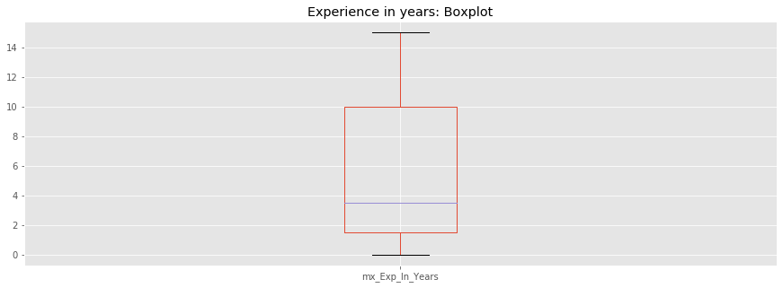

```python
latest_use['mx_Exp_In_Years'].plot(kind = 'box')
plt.title('Experience in years: Boxplot');
```

1. **Score** probably is system assigned, and it typically ranges between 0 to 300.

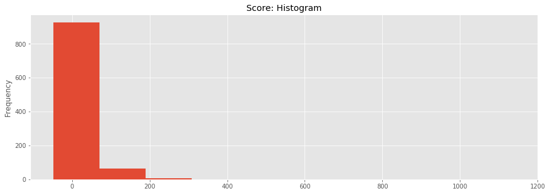

```python
latest_use['Score'].plot(kind = 'hist')
plt.title('Score: Histogram');
```

1. **Engagement Score** typically lies between 0 to 140, furthur information can be obtained in bivariate analysis, later.

[figure not shown]

```python
latest_use['EngagementScore'].plot(kind = 'hist')
plt.title('Max Experience in years: Histogram');
```

The graphs are self explainatory with key points mentioned. For quantitative variables we shall mainly plot top factors affecting the particular variable

1. mx_Preferred_Campus
2. DoNotCall
3. DoNotEmail
4. Source
5. SourceMedium
6. SourceCampaign
7. ProspectStage
8. mx_Current_Interested_Program

```python
def plot_top_n(s, n=5):
    '''
    returns a plot of top n factors for univariate analysis

    parameters:
    --------------
    s: pd.Series
    n: number of factors of the plot required
    '''
    counts = s.str.lower().str.capitalize().value_counts()
    top_counts = counts[:n]
    top_counts.plot(kind='bar', color = 'blue')

    return counts[:n]
```

1. **Top 7 prefered campus by registered candidates**

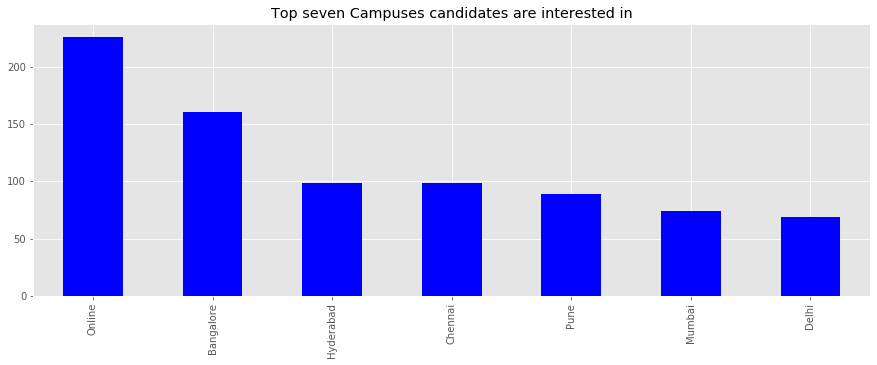

```python
plot_top_n(latest_use['mx_Preferred_Campus'], 7)
plt.title('Top seven Campuses candidates are interested in');
```

#### 2. Distribution of candidates who have asked not to call

Only a small percentage of applicants chose not to be called.

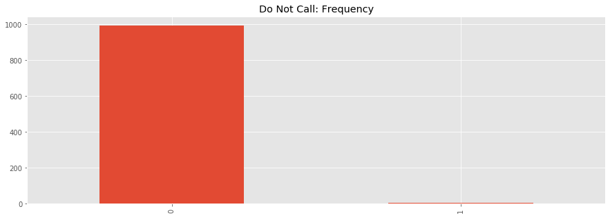

```python
latest_use['DoNotCall'].value_counts().plot(kind = 'bar')
plt.title('Do Not Call: Frequency');
```

#### 3. Distribution of candidates who have asked not to Email

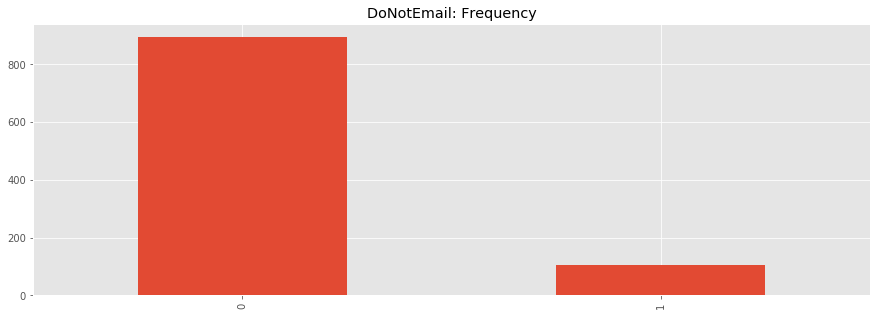

```python
latest_use['DoNotEmail'].value_counts().plot(kind = 'bar')
plt.title('DoNotEmail: Frequency');
```

#### 4. Sources of information for the candidates

Most applicants got to know about greatlearning programmes from Facebook or from google search/ads. Very few people actually visited the site and applied (~ 25)

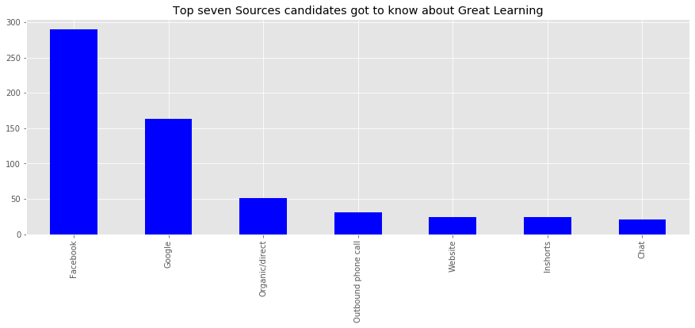

```python
plot_top_n(latest_use['Source'], 7)
plt.title('Top seven Sources candidates got to know about Great Learning')
```

#### 5. Top seven sourcesMedian for the candidates

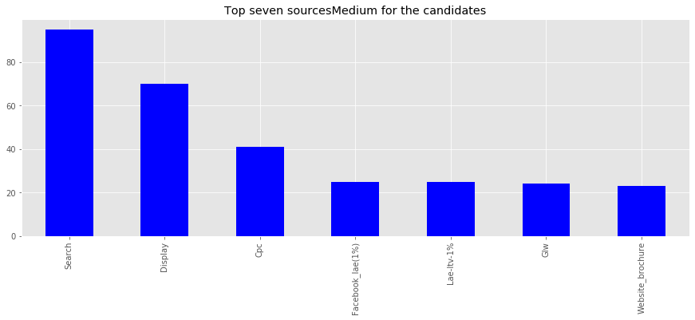

```python
plot_top_n(latest_use['SourceMedium'], 7)
plt.title('Top seven sourcesMedium for the candidates');
```

#### 6. Top seven Sources Campaigns

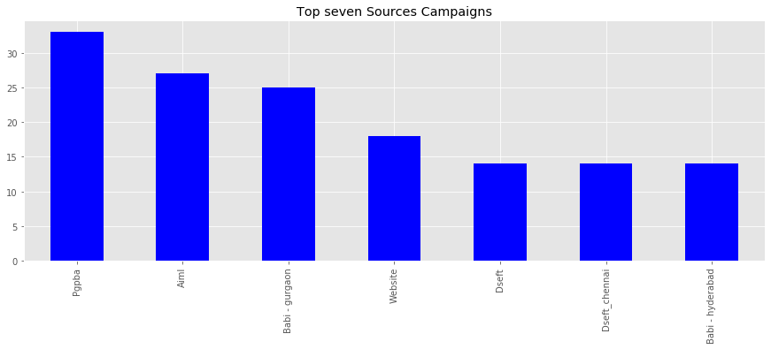

```python
plot_top_n(latest_use['SourceCampaign'], 7)
plt.title('Top seven Sources Campaigns');
```

#### 7. Various Prospect Stages of the candidate

There are very few applicants in the Latest data who have Enrolled for the course (~ 15).

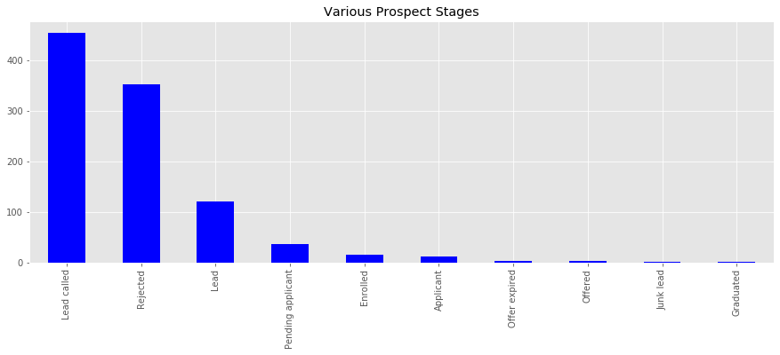

```python
plot_top_n(latest_use['ProspectStage'], 10)
plt.title('Various Prospect Stages');
```

#### 8. Top five programs candidates are interested in

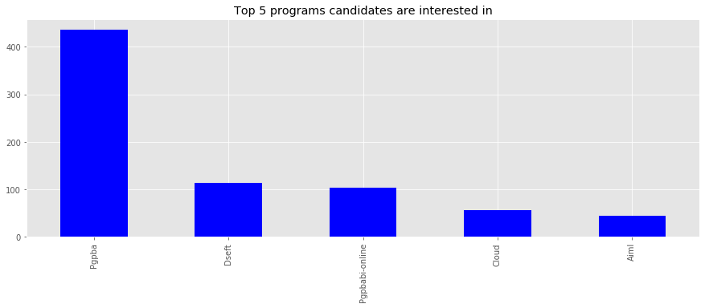

```python
n = 5
plot_top_n(latest_use['mx_Current_Interested_Program'], n)
plt.title(f'Top {n} programs candidates are interested in');
```

## Merge the two DataFrames: latest, trails

Due to merging a lot of columns are duplicated, thus the size has increased. So, for analysis part we shall only take in consideration the merged DataFrame if some findings require data from both DataFrames, else for all other cases we shall use only the respective dataFrames

```python
latest_trail = pd.merge(latest_use, trail_use, how = 'inner',
                        left_on = 'ProspectID',
                        right_on = 'RelatedProspectId')
```

### Exploring the merged DataFrame

1. Drop related columns
2. Removing duplicates
3. find info, summary etc

```python
#removing duplicates

latest_trail.drop_duplicates(inplace = True)
```

```python
latest_trail.info()
```

```
<class 'pandas.core.frame.DataFrame'>
Int64Index: 6799 entries, 0 to 6855
Data columns (total 21 columns):
ProspectID                            6799 non-null object
CreatedOn_x                           6799 non-null datetime64[ns]
mx_Preferred_Campus                   6491 non-null object
mx_Exp_In_Years                       6470 non-null float64
DoNotCall                             6799 non-null int64
DoNotEmail                            6799 non-null int64
Source                                6407 non-null object
SourceMedium                          6485 non-null object
SourceCampaign                        5357 non-null object
ProspectStage                         6799 non-null object
Score                                 6792 non-null float64
EngagementScore                       6792 non-null float64
mx_Current_Interested_Program         6792 non-null object
RelatedProspectId                     6799 non-null object
ActivityName                          6799 non-null object
CreatedOn_y                           6799 non-null datetime64[ns]
mx_Preferred_Campus_Post              6430 non-null object
ProspectStage_Pre                     6260 non-null object
ProspectStage_Post                    6778 non-null object
mx_Current_Interested_Program_Pre     6228 non-null object
mx_Current_Interested_Program_Post    6770 non-null object
dtypes: datetime64[ns](2), float64(3), int64(2), object(14)
memory usage: 1.1+ MB
```

```python
# Dropping unnecessary columns

latest_trail.drop('RelatedProspectId', axis = 1, inplace= True)
```

```python
# changing the name of the source in a proper way

latest_use['Source'] = latest_use['Source'].str.lower().str.capitalize()
```

```python
latest_trail.info()
```

```
<class 'pandas.core.frame.DataFrame'>
Int64Index: 6799 entries, 0 to 6855
Data columns (total 20 columns):
ProspectID                            6799 non-null object
CreatedOn_x                           6799 non-null datetime64[ns]
mx_Preferred_Campus                   6491 non-null object
mx_Exp_In_Years                       6470 non-null float64
DoNotCall                             6799 non-null int64
DoNotEmail                            6799 non-null int64
Source                                6407 non-null object
SourceMedium                          6485 non-null object
SourceCampaign                        5357 non-null object
ProspectStage                         6799 non-null object
Score                                 6792 non-null float64
EngagementScore                       6792 non-null float64
mx_Current_Interested_Program         6792 non-null object
ActivityName                          6799 non-null object
CreatedOn_y                           6799 non-null datetime64[ns]
mx_Preferred_Campus_Post              6430 non-null object
ProspectStage_Pre                     6260 non-null object
ProspectStage_Post                    6778 non-null object
mx_Current_Interested_Program_Pre     6228 non-null object
mx_Current_Interested_Program_Post    6770 non-null object
dtypes: datetime64[ns](2), float64(3), int64(2), object(13)
memory usage: 1.1+ MB
```

```python
latest_use['Source'].unique()
```

```
array(['Google', 'Facebook', 'Zopim chat', 'Email', nan, 'Main url',
       'Organic/direct', 'Website', 'Chat', 'Glw', 'Brochuremail', 'Aim',
       'Linkedin', 'Quora', 'Zirca', 'Brochuremail-bacp', 'Sms',
       'Outbound phone call', 'Customer referral', 'Naukri',
       'Collegedunia', 'Great lakes website', 'Direct', 'Bing',
       'Inshorts', 'Freshersworld', 'Organic search', 'Cdb',
       'Inbound phone call', 'Organic', 'Demail', 'Olp', 'Direct traffic',
       'Timesjob', 'Youtube', 'Website-contactus', 'Website-popup',
       'Zirca-cloud', 'Jobsforher', 'Taboola', 'Avm'], dtype=object)
```

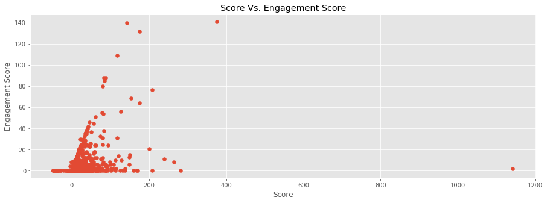

```python
plt.scatter(x= latest['Score'], y=latest['EngagementScore'])
plt.xlabel('Score')
plt.ylabel('Engagement Score')
plt.title('Score Vs. Engagement Score')
```

```python
latest_trail['mx_Exp_In_Years'].value_counts()
```

```
0.0     1642
10.0     991
6.5      886
1.5      742
3.5      538
        ...
13.5     442
4.0      423
2.5      318
1.0        2
7.0        2
Name: mx_Exp_In_Years, Length: 11, dtype: int64
```

```python
latest_trail['ProspectStage_Pre'].value_counts()
```

```
Lead                 2189
Lead Called          1978
Applicant             837
Rejected              449
Pending Applicant     367
                     ...
Offer Expired          33
Offer Accepted          4
Graduated               2
Invalid                 2
Junk Lead               2
Name: ProspectStage_Pre, Length: 13, dtype: int64
```

## Bivariate Analysis on latest focussing on Prospect Stage = 'Enrollment'

Plottinga and other univariate and bivariate analysis

```python
def make_boxplot(x, y, data, showfliers=False):
    '''
    A simple plot function with customised titles

    parameters:
    ------------
    x: pd.Series
    y: pd.Series
    data: the corrresponding data frame
    showfliers: default = False

    returns:
    ----------
    A plot with title

    '''
    fig, ax = plt.subplots(figsize = (15,7))
    sns.boxplot(x= x, y = y, data = data, ax = ax, showfliers=showfliers)
    plt.title(f'{y} for different {x}')
```

#### 1. Experience in years of the various ProspectStages

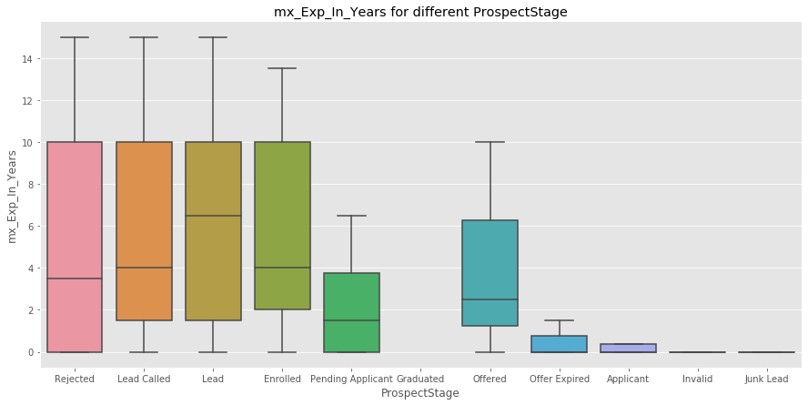

```python
make_boxplot(x= 'ProspectStage', y = 'mx_Exp_In_Years', data = latest_use)
```

#### Prospect Stages vs various scores.

This shows the people who have enrolled have a higher interquartile range of scores, which shows that they have probably visited the website more frequently

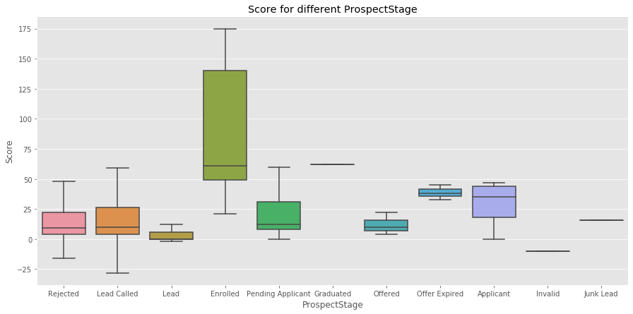

```python
make_boxplot(x= 'ProspectStage', y = 'Score', data = latest_use)
```

#### Prospect State vs Engagement Score

This shows that the engagement score is higher for candidates who have enrolled in the course, again showing their engagement with the website.

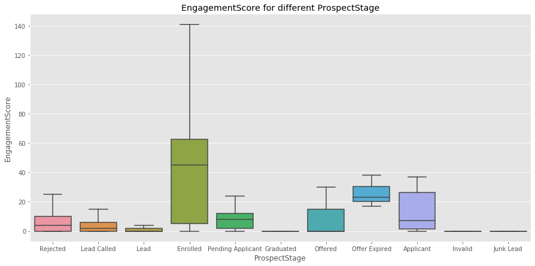

```python
make_boxplot(x= 'ProspectStage', y = 'EngagementScore', data = latest_use)
```

```python
grp_sizes = latest_use[['Source','Score']].dropna().groupby(['Source']).size()
top_grps = grp_sizes.sort_values(ascending = False)[:5].index
top_grps_dfs = latest_use.loc[np.isin(latest_use['Source'], top_grps)]
```

#### How score depends on various Sources

This shows that candidates who have visited website more times have more scores, and previously we have noticed that enrolled people have more score, so there is a chance that higher score depends on the number of time a candidate visits the website.

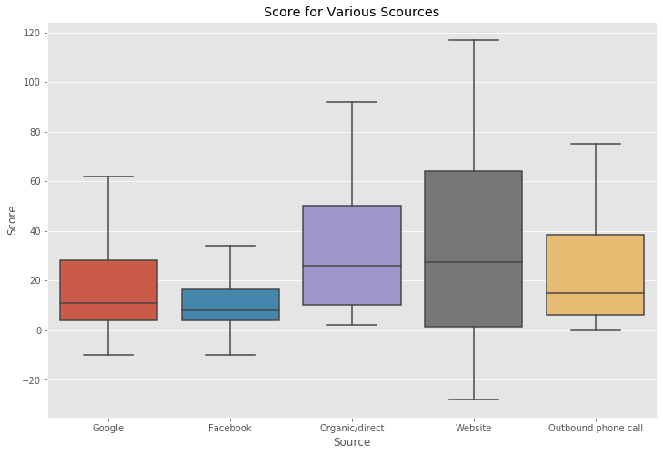

```python
fig, ax = plt.subplots(figsize = (12,8))
sns.boxplot(data = top_grps_dfs, x= 'Source', y = 'Score', ax = ax, showfliers = False);
plt.title('Score for Various Scources');
```

## Working on the trails dataframe to find out what variables help to change a lead into Enrollment

### Prospects who changed their programme

```python
pre, post = 'mx_Current_Interested_Program_Pre', 'mx_Current_Interested_Program_Post'
mismatch = trails[pre] != trails[post]
na_prog_choice = trails[[pre, post]].isna().any(axis=1)

trails.loc[mismatch &  ~na_prog_choice].head()
```

|  | RelatedProspectId | ActivityName | Status | mx_Custom_1 | mx_Custom_2 | mx_Custom_3 | mx_Custom_4 | mx_Custom_5 | mx_Custom_6 | mx_Custom_7 | mx_Custom_8 | mx_Custom_9 | mx_Custom_10 | CreatedOn | mx_Country_Post | mx_Preferred_Campus_Post | ProspectStage_Pre | ProspectStage_Post | mx_Current_Interested_Program_Pre | mx_Current_Interested_Program_Post |
| --- | --- | --- | --- | --- | --- | --- | --- | --- | --- | --- | --- | --- | --- | --- | --- | --- | --- | --- | --- | --- |
| 6 | 004d4ad9-c722-4fe4-906d-4db4362300d7 | lead_capture | existing_lead | google | PGP_BABI_PPC_BMM_Search_Brand_Bangalore_Perfor... | search | website_landing_page | NaN | NaN | NaN | NaN | NaN | NaN | 2019-02-04 11:57:18.406 | NaN | Online | Lead Called | Lead | PGPBA | PGPBABI-Online |
| 15 | 007e8363-531b-44f4-a9bf-26a9debea2b1 | lead_capture | existing_lead | Facebook | BABI - Hyderabad | LAC- 1% | website_landing_page | NaN | NaN | NaN | NaN | NaN | NaN | 2019-01-18 03:14:13.113 | India | Hyderabad | Rejected | Lead | Cloud | PGPBA-Short-Term |
| 114 | 06dec2ad-8152-479e-8ab0-038a3496e51c | lead_capture | existing_lead | Facebook | BABI - Gurgaon | Remarketing | website_landing_page | NaN | NaN | NaN | NaN | NaN | NaN | 2019-04-18 11:15:11.473 | NaN | Delhi | Lead | Lead | BACP | PGPBA |
| 137 | 0834eade-76e8-47fd-a32f-9c4ed012c714 | lead_capture | existing_lead | Facebook | BABI - Hyderabad | LAE-LTV1 | website_landing_page | NaN | NaN | NaN | NaN | NaN | NaN | 2019-05-04 05:48:59.142 | NaN | Hyderabad | Lead | Lead | PGPM-Ex | PGPBA-Short-Term |
| 154 | 08978cfc-f85c-4d2f-a6f2-711103b5f757 | 8.Change Interested Program | NaN | PGPAIML-Online | NaN | NaN | NaN | NaN | NaN | NaN | NaN | NaN | NaN | 2019-02-27 07:08:00.000 | NaN | Mumbai | Lead Called | Lead Called | AIML | PGPAIML-Online |

#### Was there a change in preferance of programme applicant was interested in? (pre vs post)

```python
def plot_comp_barplot(c1, c2, data):
    c1_c2_comp = make_categorical_freq_table([c1, c2], trails).reset_index()
    c1_c2_comp.rename(columns={'level_0': 'Stage', 'level_1': 'Programme'}, inplace=True)

    fig, ax = plt.subplots(figsize=(24, 12))
    sns.barplot(x='Programme', y='Freq_percentage', hue='Stage', data=c1_c2_comp)
    plt.xticks(rotation=45);

    return fig, c1_c2_comp
```

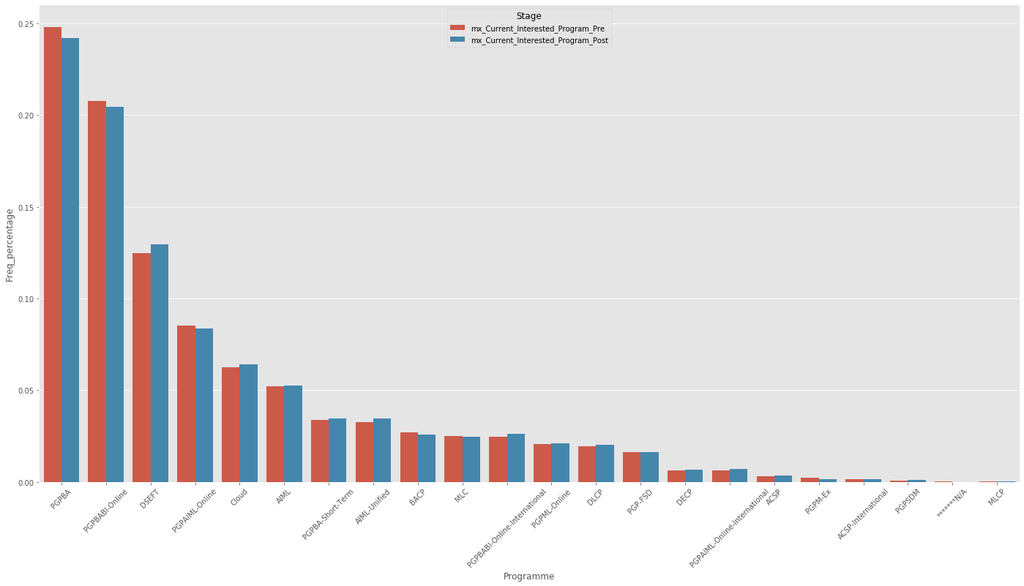

```python
pre, post = 'mx_Current_Interested_Program_Pre', 'mx_Current_Interested_Program_Post'
fig, pre_post_comp = plot_comp_barplot(pre, post, trails)
```

The above graph shows that, at the pre and the post stage people have chnaged their programes.

#### Was there a change in ProspectStage?

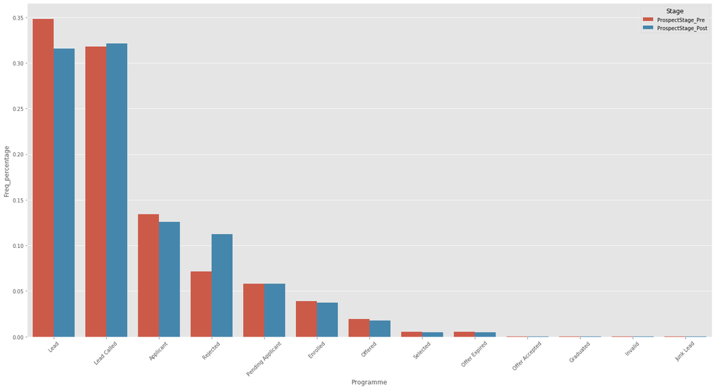

```python
fig, pre_post_comp = plot_comp_barplot('ProspectStage_Pre', 'ProspectStage_Post', trails)
```

This above graph shows the percentage of changes of the prospect stage.

1. for lead, the change percentage is significant showing that a lead is followed up after their first time, so a decrease
2. There is not much significant change in the 'Enrolled' part

#### Top ten activity of the candidates

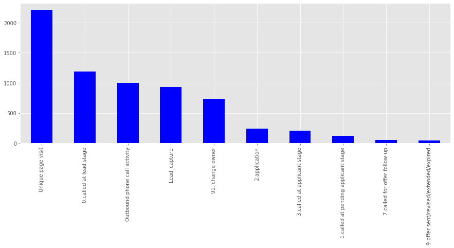

```python
plot_top_n(trails['ActivityName'], 10);
```

#### The various status, top 10

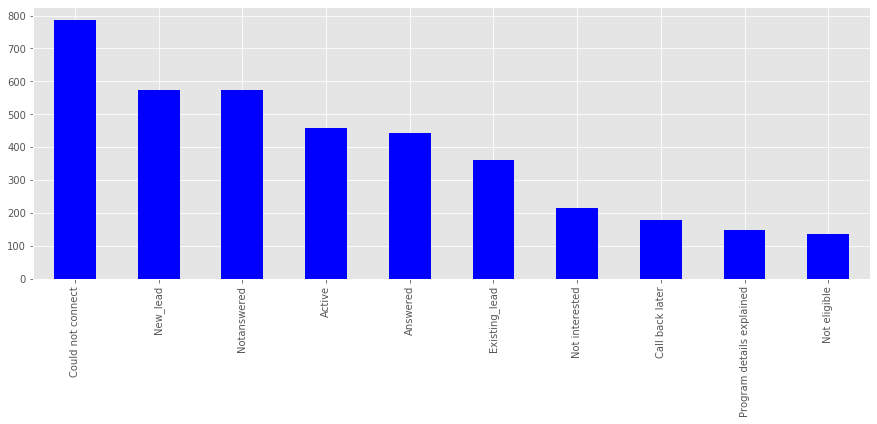

```python
plot_top_n(trails['Status'], 10);
```

#### Top ten post prospects

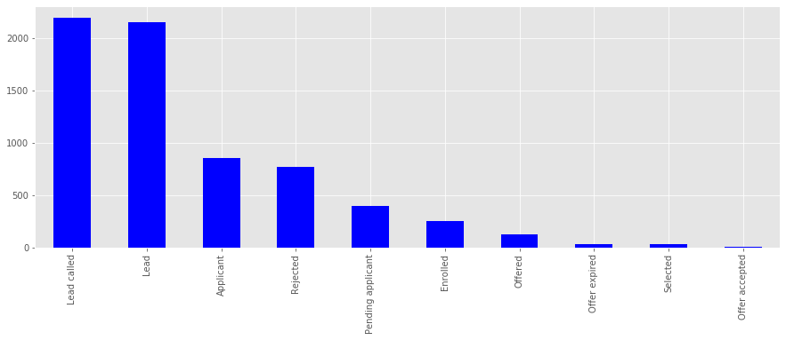

```python
plot_top_n(trails['ProspectStage_Post'], 10);
```

#### Enrolled DataFrame

- We not create a seperate DataFrame for those candidates for whom the pre stage was not 'enrolled' while the post stage was 'enrolled'
- Out of 15 enrolled cases among 1000 prospects, only 11 has been confirmed in the post stage
- This data frame should give us the intuition or the que to find out the variables

```python
enrolled = trails.loc[(trails['ProspectStage_Pre'] != 'Enrolled') & (trails['ProspectStage_Post'] == 'Enrolled')]
enrolled
```

|  | RelatedProspectId | ActivityName | Status | mx_Custom_1 | mx_Custom_2 | mx_Custom_3 | mx_Custom_4 | mx_Custom_5 | mx_Custom_6 | mx_Custom_7 | mx_Custom_8 | mx_Custom_9 | mx_Custom_10 | CreatedOn | mx_Country_Post | mx_Preferred_Campus_Post | ProspectStage_Pre | ProspectStage_Post | mx_Current_Interested_Program_Pre | mx_Current_Interested_Program_Post |
| --- | --- | --- | --- | --- | --- | --- | --- | --- | --- | --- | --- | --- | --- | --- | --- | --- | --- | --- | --- | --- |
| 1837 | 556ee2ae-a615-4859-84aa-b9cfee8cc52c | 9.Offer Sent/Revised/Extended/Expired | Fees paid | NaN | NaN | PGPDSE-FT.B.May19 | pgpdse-ft-b-bangalore | NaN | NaN | Fully Paid | 25000 | NaN | NaN | 2019-03-20 11:12:48 | India | Bangalore | Offered | Enrolled | DSEFT | DSEFT |
| 2121 | 5d814d31-8ea0-4536-8e09-b1dbc09a990d | 9.Offer Sent/Revised/Extended/Expired | Fees paid | NaN | NaN | PGP-AIML-Online.Mar19 | pgp-aiml-online | NaN | NaN | Fully Paid | 25000 | NaN | NaN | 2019-03-08 01:49:00 | India | Online | Offered | Enrolled | PGPAIML-Online | PGPAIML-Online |
| 3086 | 7fcb9582-f781-4d7e-adab-453de685cbae | 9.Offer Sent/Revised/Extended/Expired | Fees paid | NaN | NaN | PGP-BABI-Online.Apr19 | pgp-babi-online | NaN | NaN | Fully Paid | 25000 | NaN | NaN | 2019-03-22 12:21:45 | India | Online | Offer Accepted | Enrolled | PGPBABI-Online | PGPBABI-Online |
| 5023 | c03d902f-f221-4c07-adb1-b0b807a1b913 | 9.Offer Sent/Revised/Extended/Expired | Fees paid | NaN | NaN | 2018-10-01 00:00:00 | pgpdse-ft-b-bangalore | NaN | NaN | Fully Paid | 265000 | NaN | NaN | 2019-01-18 05:50:08 | NaN | Bangalore | Applicant | Enrolled | DSEFT | DSEFT |
| 5302 | c945b7a2-b4ec-406f-bf1a-58b78df27797 | 9.Offer Sent/Revised/Extended/Expired | Fees paid | NaN | NaN | PGP-BABI-Online.Feb19 | pgp-babi-online | NaN | NaN | Fully Paid | 160000 | NaN | NaN | 2019-01-25 12:21:11 | India | Online | Offered | Enrolled | PGPBABI-Online | PGPBABI-Online |
| ... | ... | ... | ... | ... | ... | ... | ... | ... | ... | ... | ... | ... | ... | ... | ... | ... | ... | ... | ... | ... |
| 5504 | d0c8bf8c-ac97-4ab1-ac52-2c2a125fc984 | 9.Offer Sent/Revised/Extended/Expired | Fees paid | NaN | NaN | NaN | NaN | NaN | NaN | Fully Paid | NaN | NaN | NaN | 2018-12-26 16:09:12 | India | Online | Offer Expired | Enrolled | PGPAIML-Online | PGPAIML-Online |
| 5527 | d0d12797-405f-41d3-8a88-96c62d4bfa0e | 9.Offer Sent/Revised/Extended/Expired | Fees paid | NaN | NaN | PGP-BABI-Online.Mar19 | pgp-babi-online | NaN | NaN | Fully Paid | 25000 | NaN | NaN | 2019-02-24 14:16:07 | India | Online | Offered | Enrolled | PGPBABI-Online | PGPBABI-Online |
| 5744 | d968a55d-bf58-4bb1-b9ee-564861559519 | 9.Offer Sent/Revised/Extended/Expired | Fees paid | NaN | NaN | PGP-BABI-Online.Jan19 | pgp-babi-online | NaN | NaN | Fully Paid | NaN | NaN | NaN | 2019-01-06 08:01:58 | India | Online | Offered | Enrolled | PGPBABI-Online | PGPBABI-Online |
| 6097 | e41b9873-7e88-4f97-90ad-e2661231441e | 9.Offer Sent/Revised/Extended/Expired | Fees paid | NaN | NaN | PGP-AIML.B.Jun19 | pgpaiml-b-bangalore1 | NaN | NaN | Fully Paid | 50000 | NaN | NaN | 2019-05-17 16:05:17 | India | Bangalore | Offer Accepted | Enrolled | AIML | AIML |
| 6501 | f40771bd-b640-4c26-8f41-1489d452d4fa | 9.Offer Sent/Revised/Extended/Expired | Fees paid | NaN | NaN | PGP-BABI-Online.Apr19 | pgp-babi-online | NaN | NaN | Fully Paid | 25000 | NaN | NaN | 2019-03-31 05:49:45 | India | Online | Offered | Enrolled | PGPBABI-Online | PGPBABI-Online |

11 rows × 20 columns

```python
#Unique enrolled whose state has changed

enrolled['RelatedProspectId'].nunique()
```

```
11
```

```python
trails['ProspectStage_Post'].unique()
```

```
array(['Lead Called', 'Lead', 'Rejected', 'Pending Applicant',
       'Applicant', 'Selected', 'Offered', 'Offer Expired', 'Invalid',
       nan, 'Enrolled', 'Graduated', 'Offer Accepted', 'Junk Lead'],
      dtype=object)
```

```python
# we are now merging the two enrolled data parts from the two data frame latest, trails

enrolled_mrgd = pd.merge(latest, enrolled, how='inner', left_on='ProspectID', right_on='RelatedProspectId')
enrolled_mrgd.head()
```

|  | ProspectID | CreatedOn_x | mx_Country | mx_Preferred_Campus | mx_Exp_In_Years | DoNotCall | DoNotEmail | mx_Mode_of_Instruction | Source | SourceMedium | ... | mx_Custom_8 | mx_Custom_9 | mx_Custom_10 | CreatedOn_y | mx_Country_Post | mx_Preferred_Campus_Post | ProspectStage_Pre | ProspectStage_Post | mx_Current_Interested_Program_Pre | mx_Current_Interested_Program_Post |
| --- | --- | --- | --- | --- | --- | --- | --- | --- | --- | --- | --- | --- | --- | --- | --- | --- | --- | --- | --- | --- | --- |
| 0 | d968a55d-bf58-4bb1-b9ee-564861559519 | 2019-01-01 15:02:23 | India | Online | 8-12 Years | 0 | 0 | NaN | brochuremail | button | ... | NaN | NaN | NaN | 2019-01-06 08:01:58 | India | Online | Offered | Enrolled | PGPBABI-Online | PGPBABI-Online |
| 1 | f40771bd-b640-4c26-8f41-1489d452d4fa | 2019-03-26 12:14:24 | India | Online | 5-8 Years | 0 | 0 | NaN | Customer Referral | Browser | ... | 25000 | NaN | NaN | 2019-03-31 05:49:45 | India | Online | Offered | Enrolled | PGPBABI-Online | PGPBABI-Online |
| 2 | c945b7a2-b4ec-406f-bf1a-58b78df27797 | 2019-01-21 17:13:05 | India | Online | 8-12 Years | 0 | 0 | NaN | google | search | ... | 160000 | NaN | NaN | 2019-01-25 12:21:11 | India | Online | Offered | Enrolled | PGPBABI-Online | PGPBABI-Online |
| 3 | e41b9873-7e88-4f97-90ad-e2661231441e | 2019-05-12 11:12:23 | India | Bangalore | 3-5 Years | 0 | 0 | NaN | demail | earticle | ... | 50000 | NaN | NaN | 2019-05-17 16:05:17 | India | Bangalore | Offer Accepted | Enrolled | AIML | AIML |
| 4 | d0d12797-405f-41d3-8a88-96c62d4bfa0e | 2019-02-20 14:41:51 | India | Online | 8-12 Years | 0 | 0 | NaN | google | search | ... | 25000 | NaN | NaN | 2019-02-24 14:16:07 | India | Online | Offered | Enrolled | PGPBABI-Online | PGPBABI-Online |

5 rows × 44 columns

num_assoc: how many times each lead were associated either through visiting the webpage, or they were called or sent an email for offer etc

```python
num_assoc = trails['RelatedProspectId'].value_counts()
num_assoc.name = 'num_assoc'
num_assoc = pd.DataFrame(num_assoc)
num_assoc = num_assoc.reset_index()
num_assoc.rename(columns={'index': 'ProspectID'}, inplace=True)
num_assoc
```

|  | ProspectID | num_assoc |
| --- | --- | --- |
| 0 | c945b7a2-b4ec-406f-bf1a-58b78df27797 | 174 |
| 1 | 8ce417c9-db72-4f75-a7a0-f6d327a658a0 | 83 |
| 2 | 744d0317-0207-40b1-bc6a-c0b8814af774 | 68 |
| 3 | f40771bd-b640-4c26-8f41-1489d452d4fa | 65 |
| 4 | d0d12797-405f-41d3-8a88-96c62d4bfa0e | 60 |
| ... | ... | ... |
| 995 | 49991a5e-5629-49c5-a3fb-b822420e055a | 1 |
| 996 | 7e3038d1-19ec-4d86-947a-2a5332a90253 | 1 |
| 997 | eb922704-ac5b-4556-ad69-559cd67f2ef6 | 1 |
| 998 | c3d70f62-0846-4964-a45f-1832d3343637 | 1 |
| 999 | c643088a-1568-48be-97cf-271d7e69570b | 1 |

1000 rows × 2 columns

This DataFrame d shows how many times the candidates have visited the website, their engagementscore, score, and year of experiences

```python
d = pd.merge(num_assoc, latest_use[['ProspectID', 'EngagementScore', 'Score', 'mx_Exp_In_Years']])
d
```

|  | ProspectID | num_assoc | EngagementScore | Score | mx_Exp_In_Years |
| --- | --- | --- | --- | --- | --- |
| 0 | c945b7a2-b4ec-406f-bf1a-58b78df27797 | 174 | 141.0 | 376.0 | 10.0 |
| 1 | 8ce417c9-db72-4f75-a7a0-f6d327a658a0 | 83 | 77.0 | 208.0 | 1.5 |
| 2 | 744d0317-0207-40b1-bc6a-c0b8814af774 | 68 | 24.0 | 94.0 | 0.0 |
| 3 | f40771bd-b640-4c26-8f41-1489d452d4fa | 65 | 132.0 | 175.0 | 6.5 |
| 4 | d0d12797-405f-41d3-8a88-96c62d4bfa0e | 60 | 56.0 | 126.0 | 10.0 |
| ... | ... | ... | ... | ... | ... |
| 995 | 49991a5e-5629-49c5-a3fb-b822420e055a | 1 | 2.0 | 9.0 | 6.5 |
| 996 | 7e3038d1-19ec-4d86-947a-2a5332a90253 | 1 | 0.0 | 0.0 | 3.5 |
| 997 | eb922704-ac5b-4556-ad69-559cd67f2ef6 | 1 | 0.0 | 0.0 | NaN |
| 998 | c3d70f62-0846-4964-a45f-1832d3343637 | 1 | 0.0 | 0.0 | NaN |
| 999 | c643088a-1568-48be-97cf-271d7e69570b | 1 | 0.0 | 2.0 | 0.0 |

1000 rows × 5 columns

#### The correlation between the associated numbers and the engagement score, score, years of exp

> more than 0.5 can be considered as a high correlation

```python
d.corr()
```

|  | num_assoc | EngagementScore | Score | mx_Exp_In_Years |
| --- | --- | --- | --- | --- |
| num_assoc | 1.000000 | 0.671228 | 0.385731 | 0.003847 |
| EngagementScore | 0.671228 | 1.000000 | 0.324604 | -0.033588 |
| Score | 0.385731 | 0.324604 | 1.000000 | 0.022977 |
| mx_Exp_In_Years | 0.003847 | -0.033588 | 0.022977 | 1.000000 |

```python
latest.columns
```

```
Index(['ProspectID', 'CreatedOn', 'mx_Country', 'mx_Preferred_Campus',
       'mx_Exp_In_Years', 'DoNotCall', 'DoNotEmail', 'mx_Mode_of_Instruction',
       'Source', 'SourceMedium', 'SourceCampaign', 'ProspectStage', 'Score',
       'EngagementScore', 'mx_Current_Interested_Program',
       'mx_Application_Date', 'mx_Industry', 'mx_UG_Degree',
       'mx_UG_Passing_Year', 'mx_PG_Degree', 'mx_PG_Passing_Year',
       'mx_Batch_Code', 'mx_City', 'mx_Device_details'],
      dtype='object')
```

```
Aiml                                              2
Exact_search_application_bangalore_performance    1
Pgpba                                             1
Pt                                                1
Lms                                               1
Name: SourceCampaign, dtype: int64
```

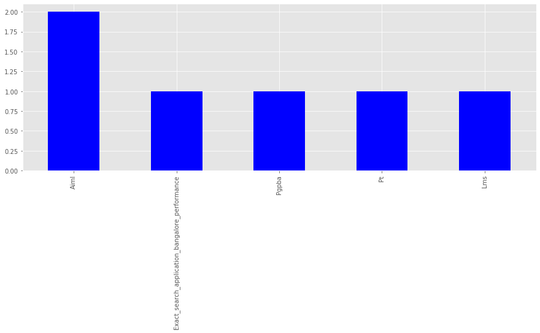

```python
plot_top_n(enrolled_mrgd['SourceCampaign'])
```

```
Organic/direct         3
Google                 2
Customer referral      2
Website                1
Outbound phone call    1
Name: Source, dtype: int64
```

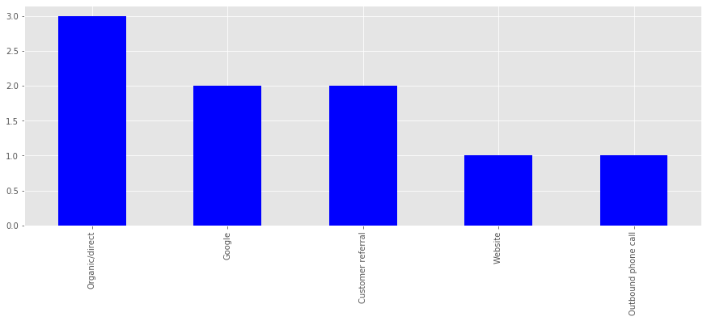

```python
plot_top_n(enrolled_mrgd['Source'])
```

```
Online       7
Bangalore    3
Mumbai       1
Name: mx_Preferred_Campus, dtype: int64
```

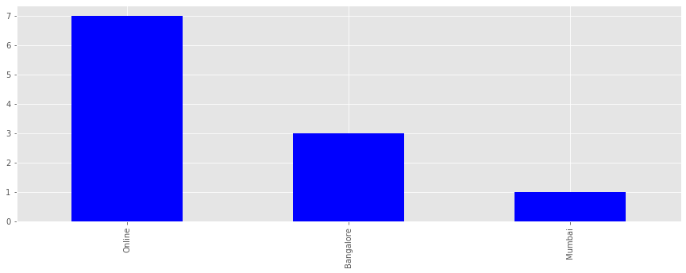

```python
plot_top_n(enrolled_mrgd['mx_Preferred_Campus'])
```

```
It & technology    4
Energy             2
Bfsi               1
Automobile         1
Manufacturing      1
Name: mx_Industry, dtype: int64
```

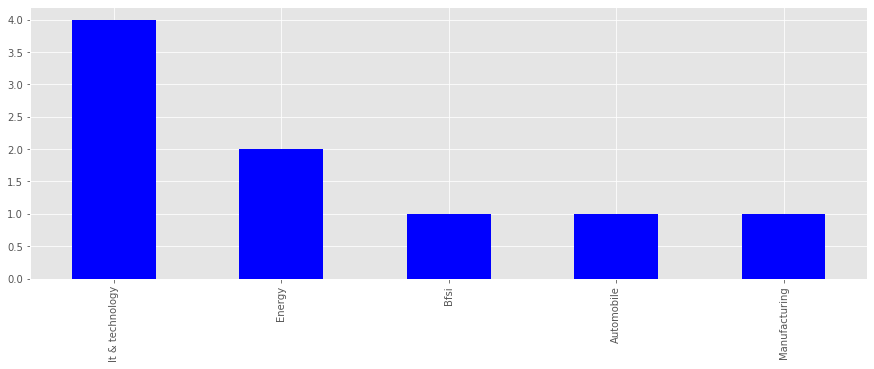

```python
plot_top_n(enrolled_mrgd['mx_Industry'])
```

```
Pgpbabi-online    5
Dseft             3
Pgpaiml-online    2
Aiml              1
Name: mx_Current_Interested_Program, dtype: int64
```

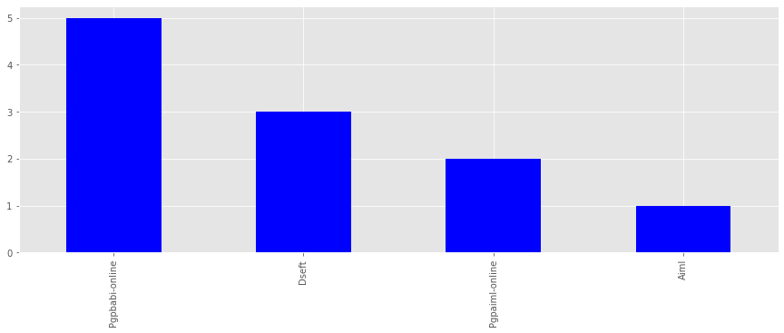

```python
 plot_top_n(enrolled_mrgd['mx_Current_Interested_Program'])
```

```
8-12 years    3
0 years       2
1-2 years     2
3-5 years     2
2-3 years     1
Name: mx_Exp_In_Years, dtype: int64
```

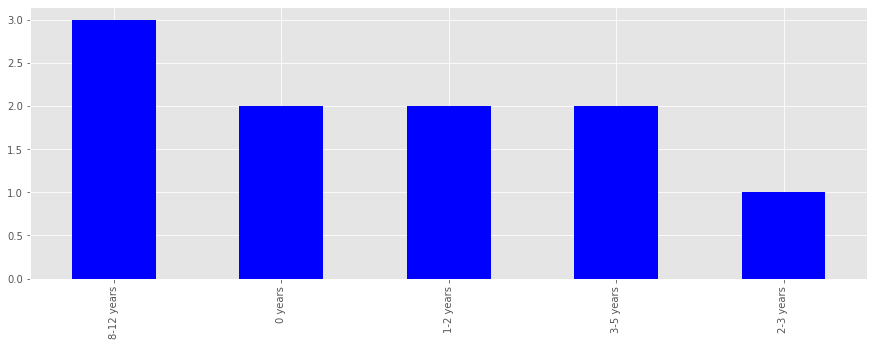

```python
 plot_top_n(enrolled_mrgd['mx_Exp_In_Years'])
```

In the Latest table, there are unique PrsopectIds of 1000 candidates among whom only 15 people enrolled. Trails contains information who were repeatedly contacted a number of times at various stages till they enrolled. There are 11 people who have bought the course in the post stage, also num_assoc and engagement score has a high correlation, this shows that the number of times the candidate visit the website, their enrollment have increased. This somewhat shows that people who have bought the course did have genuine interest in GreatLearnings.

Since the data is very limited, only 11 data points are available for people who have changed their status to 'enrolled' from pre Prospect Stage to post Prospect stage so the inferences will have a high tendency of biasness. However, an intuitive, or a hunch that can be considered from the above graphs are as follows:

The previous graphs shows that most enrolled poeple have a

This was all the details that the data was describing. Thank you